# Clase 4: Visualización de datos en R

# Transformaciones

Los datos crudos a veces engañan. Antes de graficar hay que preguntarse: **¿estoy midiendo lo que quiero medir, o estoy midiendo otra cosa?**

En este caso: un municipio puede tener muchas taquerías simplemente porque es grande, no porque sea particularmente “taquero”. Si graficamos el conteo crudo, el ranking lo van a dominar siempre las ciudades más pobladas — no las más densas en taquerías.

La solución es **normalizar**: dividir el conteo entre alguna medida del tamaño del municipio. Idealmente usaríamos población, pero eso no está en el DENUE. Lo que sí tenemos es el número de colonias distintas por municipio, que funciona como proxy razonable del tamaño urbano.

Dos transformaciones que hacemos:

- `n_distinct(colonia)` — cuenta cuántas colonias distintas tiene cada municipio
- `n_taquerias / n_colonias` — el ratio: taquerías por unidad de tamaño urbano

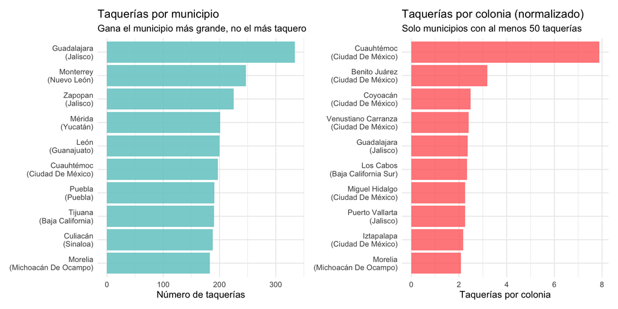

```r
# ── Datos crudos: taquerías por municipio ─────────────────────────────────────

taquerias_por_municipio <- taquerias %>%
  count(municipio, entidad, sort = TRUE) %>%
  slice_head(n = 10) %>%
  mutate(
    # str_to_title: primera letra mayúscula, resto minúscula
    # "CIUDAD DE MÉXICO" → "Ciudad De México"
    # \n es un salto de línea — para que la etiqueta quepa mejor en el eje y
    etiqueta = paste0(municipio, "\n(", str_to_title(entidad), ")")
  )

p_crudo <- taquerias_por_municipio %>%
  mutate(etiqueta = fct_reorder(etiqueta, n)) %>%   # ordena por n, no alfabéticamente
  ggplot(aes(x = n, y = etiqueta)) +
  geom_col(fill = "darkslategray3", alpha = 0.9) +
  labs(title   = "Taquerías por municipio",
       subtitle = "Gana el municipio más grande, no el más taquero",
       x = "Número de taquerías", y = NULL) +
  theme_minimal()

# ── Transformación: taquerías por colonia ─────────────────────────────────────

colonias_por_municipio <- taquerias %>%
  group_by(municipio, entidad) %>%
  summarise(
    n_taquerias = n(),
    n_colonias  = n_distinct(colonia),
    .groups     = "drop"
  ) %>%
  # filtramos municipios con pocas taquerías — distorsionan el ratio
  # un municipio con 2 taquerías en 1 colonia tiene ratio 2, pero no es relevante
  filter(n_taquerias >= 50) %>%
  mutate(
    taquerias_por_colonia = n_taquerias / n_colonias,
    # str_to_title también aquí — faltaba en la versión anterior
    etiqueta = paste0(municipio, "\n(", str_to_title(entidad), ")")
  ) %>%
  arrange(desc(taquerias_por_colonia)) %>%
  slice_head(n = 10)


p_normalizado <- colonias_por_municipio %>%
  mutate(etiqueta = fct_reorder(etiqueta, taquerias_por_colonia)) %>%
  ggplot(aes(x = taquerias_por_colonia, y = etiqueta)) +
  geom_col(fill = "indianred1", alpha = 0.8) +
  labs(title   = "Taquerías por colonia (normalizado)",
       subtitle = "Solo municipios con al menos 50 taquerías",
       x = "Taquerías por colonia", y = NULL) +
  theme_minimal()

p_crudo + p_normalizado
```

# Honestidad visual: el Factor de Mentira

El truco más común: truncar el eje y.

[figure not shown]

```r
puebla_sin_capital <- taquerias %>%
  filter(entidad == "PUEBLA") %>%
  count(municipio, sort = TRUE) %>%
  filter(municipio != "Puebla", n >= 9) %>%   # quitamos la capital y municipios muy chicos
  mutate(municipio = fct_reorder(municipio, n))

p_mentira <- puebla_sin_capital %>%
  ggplot(aes(x = n, y = municipio)) +
  geom_col(fill = "firebrick", alpha = 0.8) +
  coord_cartesian(xlim = c(10, max(puebla_sin_capital$n) * 1.05)) +
  scale_x_continuous(breaks = c(8, 15, 20, 25, 30, 35)) +
  labs(title    = "Versión truncada (eje empieza en 10)",
       subtitle = "San Andrés Cholula parece tener 4 veces más que Atlixco",
       x = "Número de taquerías", y = NULL) +
  theme_minimal()

p_honesta <- puebla_sin_capital %>%
  ggplot(aes(x = n, y = municipio)) +
  geom_col(fill = "steelblue", alpha = 0.8) +
  scale_x_continuous(breaks = c(0, 8, 15, 20, 25, 30, 35)) +
  labs(title    = "Versión honesta (eje empieza en 0)",
       subtitle = "Los mismos datos en proporción real",
       x = "Número de taquerías", y = NULL) +
  theme_minimal()

p_mentira + p_honesta
```

# Facetas: comparar el mismo patrón entre grupos

`facet_wrap` divide una gráfica en paneles — uno por cada valor de una variable. Es mejor que hacer múltiples gráficas a mano porque la escala es consistente entre paneles y el código es mucho más corto.

[figure not shown]

```r
taquerias %>%
  # nos quedamos con 6 estados — suficientes para llenar 3 filas de 2 paneles
  # más de 6 paneles empieza a verse apretado
  filter(
    entidad %in% c("CIUDAD DE MÉXICO", "PUEBLA",
                   "GUANAJUATO", "JALISCO",
                   "NUEVO LEÓN", "OAXACA")
  ) %>%
  # contamos por entidad Y estrato — necesitamos ambas para el facet
  count(entidad, estrato) %>%
  group_by(entidad) %>%
  mutate(
    # porcentaje dentro de cada estado — no del total nacional
    # esto es clave: queremos comparar la distribución interna de cada estado,
    # no cuántas taquerías tiene cada uno en términos absolutos
    pct = n / sum(n) * 100,

    # str_to_title para que no salga todo en mayúsculas
    entidad = str_to_title(entidad)
  ) %>%
  ggplot(aes(x = pct,
             y = estrato,     # estrato en y — barras horizontales, más fácil leer etiquetas
             fill = estrato)) +  # color por estrato — el mismo en todos los paneles

  # show.legend = FALSE porque el color ya está en el eje y — sería información duplicada
  geom_col(show.legend = FALSE, alpha = 0.85) +

  # etiqueta al final de cada barra con el porcentaje
  # hjust = -0.2 la empuja ligeramente a la derecha del borde de la barra
  # alternativa: hjust = 1.2 la pondría dentro de la barra
  geom_text(aes(label = paste0(round(pct, 0), "%")),
            hjust = -0.2, size = 3) +

  # ampliamos el eje x hasta 110 para que las etiquetas no queden cortadas
  scale_x_continuous(limits = c(0, 110)) +

  # colores manuales por estrato — más control que los automáticos de ggplot
  # los colores automáticos suelen ser difíciles de distinguir cuando hay 5+ categorías
  # alternativa: scale_fill_brewer(palette = "Set2") para paletas predefinidas
  scale_fill_manual(values = c(
    "6 a 10 personas"    = "steelblue",
    "11 a 30 personas"   = "orange",
    "31 a 50 personas"   = "seagreen",
    "51 a 100 personas"  = "mediumpurple",
    "101 a 250 personas" = "firebrick"
  )) +

  # facet_wrap crea un panel por cada valor de entidad
  # ~ entidad: la ~ es obligatoria, viene de la notación de fórmulas de R
  # ncol = 2: dos columnas de paneles — con 6 estados quedan 3 filas de 2
  # alternativa: ncol = 3 para 2 filas de 3, más ancho y menos alto
  facet_wrap(~ entidad, ncol = 2) +

  labs(
    title    = "Distribución de taquerías por tamaño y estado",
    subtitle = "El 88% son micronegocios (0-5 personas) — aquí vemos el resto",
    x        = "% dentro de cada estado",
    y        = NULL,   # NULL elimina la etiqueta del eje y — el estrato se explica solo
    caption  = "Fuente: DENUE, INEGI (julio 2026)"
  ) +

  # theme_minimal quita el fondo gris y deja solo las líneas de referencia
  # alternativas según contexto:
  # theme_classic()  → solo ejes, sin líneas de fondo — más formal, para papers
  # theme_bw()       → fondo blanco con cuadrícula gris — intermedio
  # theme_light()    → similar a minimal pero con bordes más marcados
  theme_minimal()
```

`facet_wrap(~ entidad)` le dice a ggplot “haz un panel por cada valor de `entidad`”. El `~` es obligatorio — viene de la notación de fórmulas de R. `ncol = 2` controla cuántas columnas tienen los paneles.

Por defecto todos los paneles comparten la misma escala, lo cual facilita la comparación. Si los volúmenes son muy distintos entre grupos, se puede agregar `scales = "free_y"` para que cada panel tenga la suya:

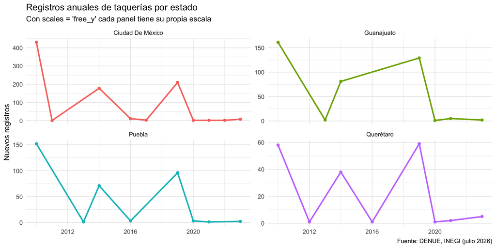

```r
# con series de tiempo — un panel por entidad
# aquí sí usamos free_y porque CDMX tiene muchos más registros que Querétaro
taquerias %>%
  filter(
    entidad %in% c("CIUDAD DE MÉXICO", "PUEBLA", "GUANAJUATO", "QUERÉTARO"),
    !is.na(año_inc), año_inc >= 2010, año_inc <= 2023
  ) %>%
  count(entidad, año_inc) %>%
  mutate(entidad = str_to_title(entidad)) %>%
  ggplot(aes(x = año_inc, y = n, color = entidad)) +
  geom_line(linewidth = 1) +
  geom_point(size = 1.5) +
  facet_wrap(~ entidad, ncol = 2, scales = "free_y") +
  labs(
    title    = "Registros anuales de taquerías por estado",
    subtitle = "Con scales = 'free_y' cada panel tiene su propia escala",
    x        = NULL,
    y        = "Nuevos registros",
    caption  = "Fuente: DENUE, INEGI (julio 2026)"
  ) +
  theme_minimal() +
  theme(legend.position = "none")   # la leyenda sobra — cada panel ya tiene título
```